# Applied Statistics: Final Assignment

Study group 8: Francois Mizrahi, Estelle Tessaro, Zhicong Hu, Chuhan Zhang, Zervaan Borok, Anuhya Yallabandi

2021-09-21

```r
library("plyr")
library("do")
library(googlesheets4)
library(tidyverse)
library(janitor)
library(skimr)
library(countrycode) # to clean up country names
library(broom)
library(car)
library(ggfortify)
library(quantmod)
library(ggplot2)
library(infer)
library(kableExtra)
library(maps)
library(tidyquant)
library(dplyr)
```

# 1 Clean data

Load the ask a manager data set

```r
ask_a_manager_2021 <- read_csv(here::here("data", "ask_a_manager_2021.csv"))
```

Skim the data set to see if there are any missing or duplicate values

```r
skimr::skim(ask_a_manager_2021)
```

Data summary

| Name | ask_a_manager_2021 |
| --- | --- |
| Number of rows | 26765 |
| Number of columns | 18 |
| _______________________ |  |
| Column type frequency: |  |
| character | 14 |
| logical | 2 |
| numeric | 1 |
| POSIXct | 1 |
| ________________________ |  |
| Group variables | None |

**Variable type: character**

| skim_variable | n_missing | complete_rate | min | max | empty | n_unique | whitespace |
| --- | --- | --- | --- | --- | --- | --- | --- |
| how_old_are_you | 0 | 1.00 | 5 | 10 | 0 | 7 | 0 |
| industry | 62 | 1.00 | 2 | 171 | 0 | 1084 | 0 |
| job_title | 0 | 1.00 | 1 | 126 | 0 | 12838 | 0 |
| additional_context_on_job_title | 19868 | 0.26 | 1 | 781 | 0 | 6612 | 0 |
| currency | 0 | 1.00 | 3 | 7 | 0 | 11 | 0 |
| additional_context_on_income | 23851 | 0.11 | 1 | 1151 | 0 | 2839 | 0 |
| country | 0 | 1.00 | 1 | 209 | 0 | 297 | 0 |
| state | 4761 | 0.82 | 4 | 114 | 0 | 125 | 0 |
| city | 23 | 1.00 | 1 | 171 | 0 | 4070 | 0 |
| overall_years_of_professional_experience | 0 | 1.00 | 9 | 16 | 0 | 8 | 0 |
| years_of_experience_in_field | 0 | 1.00 | 9 | 16 | 0 | 8 | 0 |
| highest_level_of_education_completed | 202 | 0.99 | 3 | 34 | 0 | 6 | 0 |
| gender | 155 | 0.99 | 3 | 29 | 0 | 5 | 0 |
| race | 151 | 0.99 | 5 | 125 | 0 | 47 | 0 |

**Variable type: logical**

| skim_variable | n_missing | complete_rate | mean | count |
| --- | --- | --- | --- | --- |
| other_monetary_comp | 26765 | 0 | NaN | : |
| currency_other | 26765 | 0 | NaN | : |

**Variable type: numeric**

| skim_variable | n_missing | complete_rate | mean | sd | p0 | p25 | p50 | p75 | p100 | hist |
| --- | --- | --- | --- | --- | --- | --- | --- | --- | --- | --- |
| annual_salary | 0 | 1 | 144988.1 | 5488158 | 0 | 54000 | 75712 | 110000 | 8.7e+08 | ▇▁▁▁▁ |

**Variable type: POSIXct**

| skim_variable | n_missing | complete_rate | min | max | median | n_unique |
| --- | --- | --- | --- | --- | --- | --- |
| timestamp | 0 | 1 | 2021-04-27 11:02:09 | 2021-09-14 21:55:44 | 2021-04-28 12:35:21 | 23989 |

We see that the complete rate of “other_monetary_comp” and “currency_other” is 0. Hence, we can get rid of these columns.

```r
ask_a_manager_2021 <- ask_a_manager_2021 %>%
  select( -other_monetary_comp, - currency_other)
```

Let us also filter out the data where industry, highest level of educatin, gender and race is NA

```r
ask_a_manager_2021 <- ask_a_manager_2021 %>%
  filter(!is.na(industry) & !is.na(highest_level_of_education_completed) & !is.na(gender) & !is.na(race))
```

## 1.1 Country

Now, the only columns where we have missing data is additional_context_on_job_title, additional_context_on_income, state and city

```r
unique_country_values <- unique(ask_a_manager_2021$country) %>%
  as_tibble()

unique_country_values$country_code = NA


for(i in 1:nrow(unique_country_values)){
  countryToTidy = unique_country_values$value[i]
  unique_country_values$country_code[i] = countrycode(countryToTidy, origin = 'country.name', destination = 'iso3c')
}
```

Then, find misspelled countries that has frequency higher 5 and clean the data.

```r
misspelled_countries <- ask_a_manager_2021[!(ask_a_manager_2021$country %in% (unique_country_values %>%
                                                      na.omit() %>%
                                                      select(value) %>%
                                                      pull())),]

country_list <- misspelled_countries %>%
  count(country, sort=TRUE) %>%
  filter(n >= 5) %>%
  select(country) %>%
  pull()

misspelled_countries <- misspelled_countries[misspelled_countries$country %in% country_list,]

misspelled_countries <- misspelled_countries %>%
  select(country) %>%
  unique() %>%
  mutate(country_code = ifelse(country == "Scotland" |
                                 country == "England", "GBR", ifelse(country == "NZ", "NZL", "USA"
                                 ))) %>%
  rbind((unique_country_values %>% na.omit() %>% rename(country = value)))

ask_a_manager_2021 <- ask_a_manager_2021 %>%
  left_join(misspelled_countries, by="country") %>%
  drop_na(country_code)
```

## 1.2 Currency

As salaries are expressed in different currencies we will convert all salaries to $USD. We understand that using a basic conversion using current rates opens the discussion on purchasing power parity, however we chose to ignore it in this study.

```r
from <- c("USD", "GBP", "CAD", "EUR", "AUD", "CHF", "ZAR", "SEK", "HKD", "JPY")
to <- "USD"
currency_rate <- rownames_to_column(getQuote(paste0(from, to, "=X")), "currency")[,c(1,3)] %>%
  mutate(currency = str_replace(currency, "USD=X", ""))
currency_rate[currency_rate$currency == "AUD","currency"] <- "AUD/NZD"

ask_a_manager_2021 <- left_join(ask_a_manager_2021, currency_rate, by="currency") %>%
  mutate(USD_salary = annual_salary * Last)

# We have 121 observations that has unsure currency, to let it not mess with our income variable (important variable), we decide to remove them entire.
ask_a_manager_2021 <- ask_a_manager_2021[!(is.na(ask_a_manager_2021$USD_salary)),]
```

## 1.3 Race

```r
race_list <- ask_a_manager_2021 %>%
  count(race, sort=TRUE) %>%
  filter(n >= 100) %>%
  select(race) %>%
  pull()

ask_a_manager_2021_race <- ask_a_manager_2021[ask_a_manager_2021$race %in% race_list,]
```

## 1.4 Industry

```r
industry_list <- ask_a_manager_2021 %>%
  count(industry, sort=TRUE) %>%
  filter(n >= 100) %>%
  select(industry) %>%
  pull()

ask_a_manager_2021_industry <- ask_a_manager_2021[ask_a_manager_2021$industry %in% industry_list,]
```

# 2 Analysis by Gender

Let’s do a general analysis to see how respondents are divided among gender, race and industry.

Can we suggest any racial or gender discrimination going on in relation to the salaries people have entered? If so, is this discrimination country or industry-specific? Also, do salaries vary across industries? Is there variability in these industries?

First, let’s look at gender.

```r
ask_a_manager_2021 %>%
  group_by(gender) %>%
  na.omit() %>%
  summarise(gender_count = n()) %>%
  arrange(gender_count) %>%
  kable()
```

| gender | gender_count |
| --- | --- |
| Other or prefer not to answer | 12 |
| Non-binary | 43 |
| Man | 139 |
| Woman | 796 |

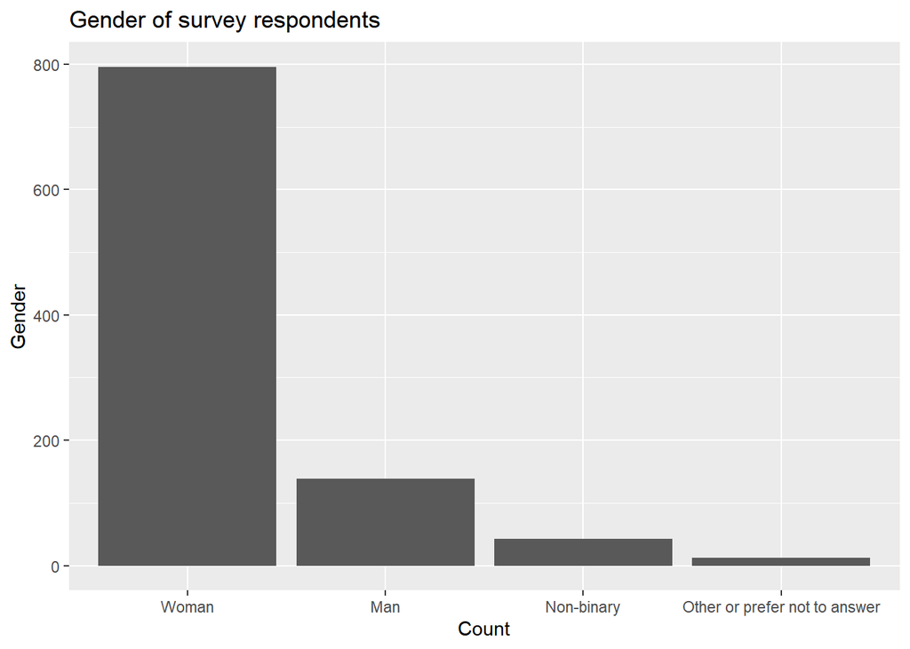

```r
ask_a_manager_2021 %>%
  group_by(gender) %>%
  na.omit() %>%
  summarise(gender_count = n()) %>%
  arrange(gender_count) %>%
  ggplot(gender_analysis, mapping = aes(x=fct_reorder(gender,-gender_count), y=gender_count)) +
  geom_col() +
  labs(title="Gender of survey respondents", x="Count", y="Gender") +
  NULL
```

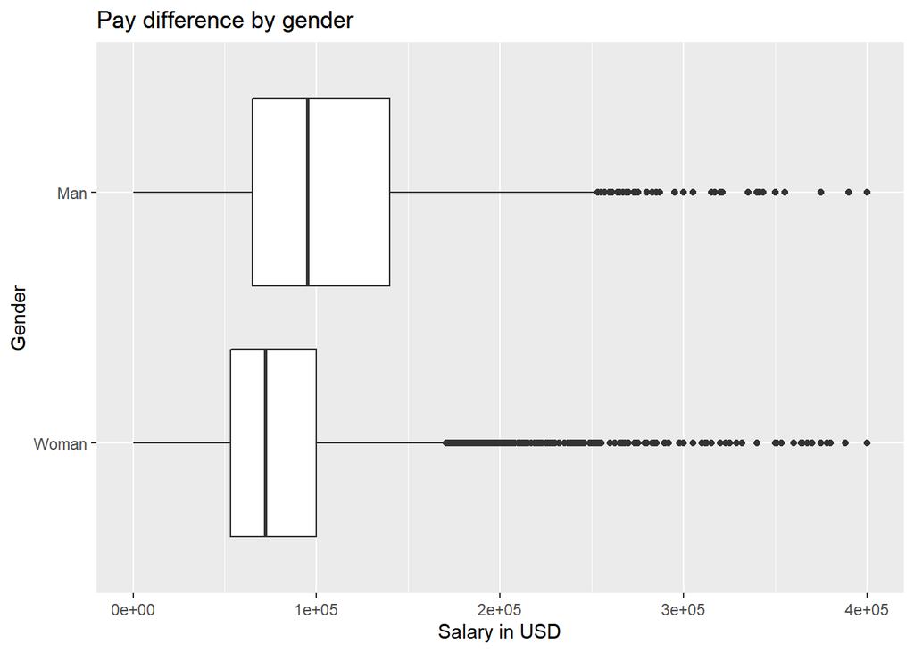

```r
ggplot(ask_a_manager_2021 %>% filter(gender == "Man" | gender == "Woman"),
       aes(x=USD_salary, y=reorder(gender,USD_salary))) +
  scale_x_log10() +
  xlim(0,400000) +
  labs(title = "Pay difference by gender", x = "Salary in USD", y = "Gender") +
  geom_boxplot()
```

> We can see that the median salary of Males is greater than women.

Let us do a null hypothesis, saying the mean sample of salary for men and women is the same

```r
# hypothesis testing using t.test()
ask_a_manager_man_women <- ask_a_manager_2021 %>%
   filter(gender == "Man" | gender == "Woman")

t.test(USD_salary ~ gender, data = ask_a_manager_man_women)
```

```
##
##  Welch Two Sample t-test
##
## data:  USD_salary by gender
## t = 2.2811, df = 4757.5, p-value = 0.02258
## alternative hypothesis: true difference in means between group Man and group Woman is not equal to 0
## 95 percent confidence interval:
##   6885.129 91071.898
## sample estimates:
##   mean in group Man mean in group Woman
##           132626.87            83648.35
```

```r
# hypothesis testing using infer package
infer_gender_salary <- ask_a_manager_man_women %>%
  specify(USD_salary ~ gender) %>%
  calculate(stat = "diff in means", order = c("Man", "Woman"))

null_dist <- ask_a_manager_man_women %>%
  # specify variables
  specify(USD_salary ~ gender) %>%

  # assume independence, i.e, there is no difference
  hypothesize(null = "independence") %>%

  # generate 1000 reps, of type "permute"
  generate(reps = 1000, type = "permute") %>%

  # calculate statistic of difference, namely "diff in means"
  calculate(stat = "diff in means", order = c("Man", "Woman"))
```

Let us see the confidence intervals for pays of men and women.

[figure not shown]

```r
  female_pay <- ask_a_manager_2021 %>%
  filter(gender == "Woman") %>%
  dplyr::summarise(gender = "Woman",
            mean_pay = mean(USD_salary, na.rm=TRUE),
            SD_pay = sd(USD_salary, na.rm=TRUE),
            count_pay = n()) %>%
  mutate(SE_pay = SD_pay/sqrt(count_pay),
         lower_CI = mean_pay - (2*SE_pay),
         upper_CI = mean_pay + (2*SE_pay))

male_pay <- ask_a_manager_2021 %>%
  filter(gender == "Man") %>%
  dplyr::summarise(gender = "Man",
            mean_pay = mean(USD_salary, na.rm=TRUE),
            SD_pay = sd(USD_salary, na.rm=TRUE),
            count_pay = n()) %>%
  mutate(SE_pay = SD_pay/sqrt(count_pay),
         lower_CI = mean_pay - (2*SE_pay),
         upper_CI = mean_pay + (2*SE_pay))

male_female_pay <- rbind(female_pay,male_pay)

ggplot(male_female_pay) +
geom_errorbar( aes(y =gender ,xmin = lower_CI, xmax= upper_CI, width =0.1, size= 2, x=mean_pay, color = gender)) +
  geom_point( aes(y = gender, x= mean_pay, size = 2, color = gender)) +
  geom_text(aes(x=mean_pay, y=gender), label = round(male_female_pay$mean_pay,2),
            hjust=0.5, vjust=-1, size=3)  +
  theme(legend.position = "none") +
  labs(title= "Do men and women have the same mean pay?", subtitle ="95% confidence intervals overlap",
      x ="Mean Pay", y="Gender")
```

```r
male_female_pay
```

```
## # A tibble: 2 x 7
##   gender mean_pay   SD_pay count_pay SE_pay lower_CI upper_CI
##   <chr>     <dbl>    <dbl>     <int>  <dbl>    <dbl>    <dbl>
## 1 Woman    83648.   66712.     20298   468.   82712.   84585.
## 2 Man     132627. 1480068.      4754 21466.   89695.  175559.
```

> We see that the confidence intervals of pays for men and women don’t overlap. Also, the confidence interval for men is huge as compared to women because the samples of men were 4754 which is ~0.25 times the sample size for women

Now, let us get the countries with most data so that we can see if the difference of pay in gender is only in specific countries

```r
ask_a_manager_2021 %>%
  group_by(country_code) %>%
  dplyr::summarise(country_code_count = n()) %>%
  arrange(- country_code_count) %>%
  head(4)
```

```
## # A tibble: 4 x 2
##   country_code country_code_count
##   <chr>                     <int>
## 1 USA                       21708
## 2 CAN                        1569
## 3 GBR                        1482
## 4 AUS                         364
```

Let us see the boxplots for pay in USA, Canada, UK and Australia

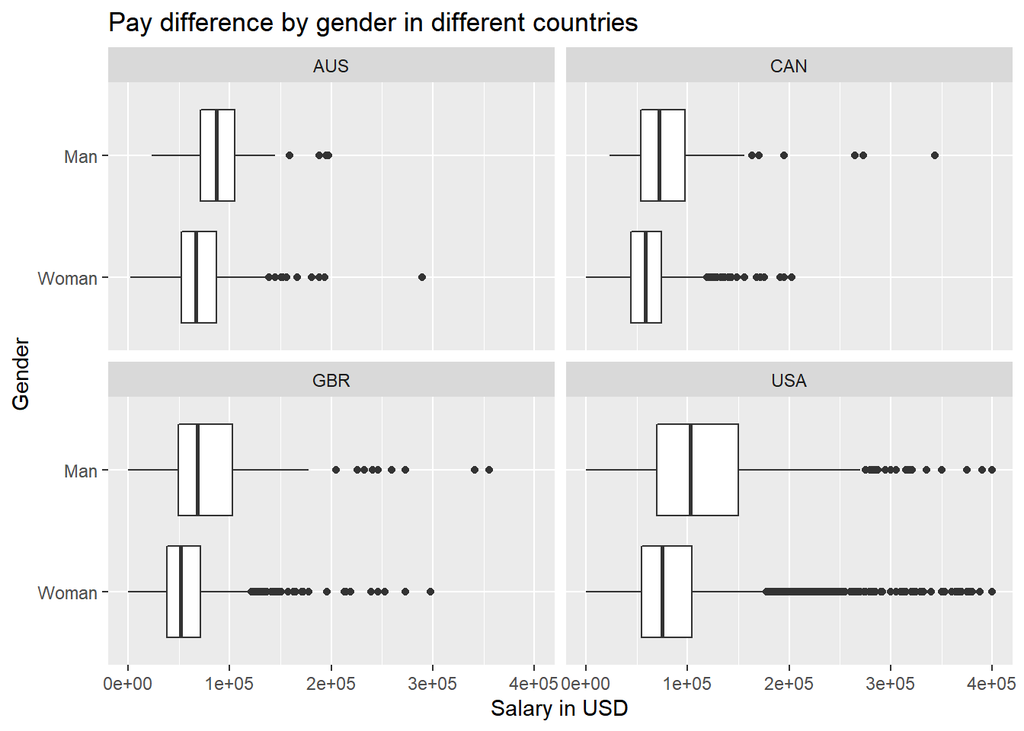

```r
ask_a_manager_2021 %>%
  filter(gender == "Man" | gender == "Woman") %>%
  filter(country_code == "USA" | country_code == "CAN" | country_code == "GBR" | country_code == "AUS" ) %>%
  ggplot(aes(x= USD_salary, y=reorder(gender,USD_salary))) +
  facet_wrap(~country_code)+
  xlim(0,400000) +
  labs(title = "Pay difference by gender in different countries ", x = "Salary in USD", y = "Gender") +
 # theme(axis.text.x = element_text(angle=90, hjust=1)) +
  geom_boxplot()
```

> We can see that the the median of salary is higher for males in all the countries

Now, let us compare the salaries of people with equal relevant experience in the field

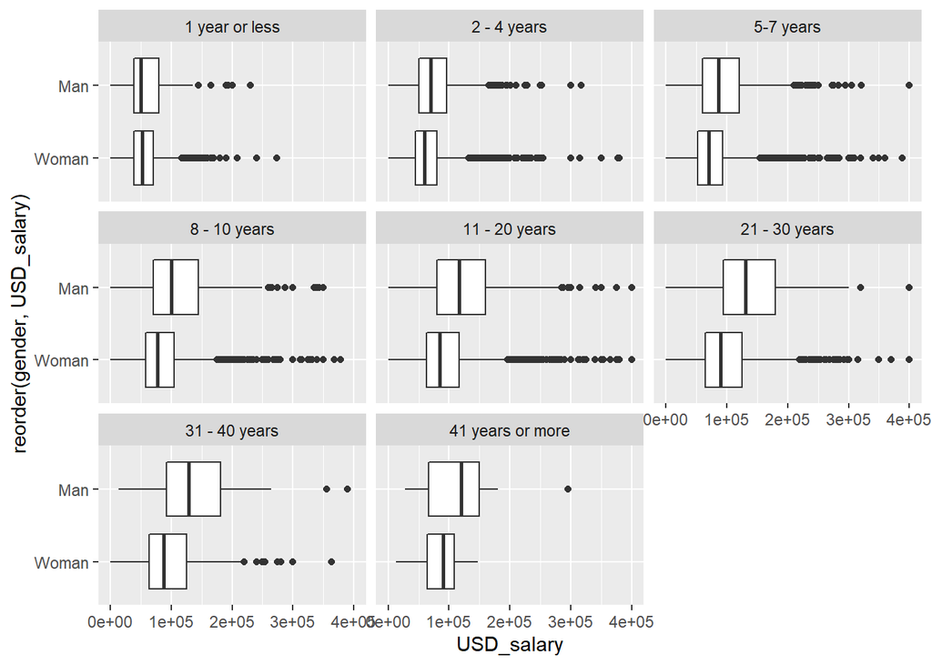

```r
ask_a_manager_2021$years_of_experience_in_field <- factor(ask_a_manager_2021$years_of_experience_in_field, levels = c("1 year or less", "2 - 4 years", "5-7 years" , "8 - 10 years", "11 - 20 years", "21 - 30 years", "31 - 40 years"  , "41 years or more"))

ask_a_manager_2021 %>%
  filter(gender == "Man" | gender == "Woman") %>%
  ggplot(aes(x= USD_salary, y=reorder(gender,USD_salary))) +
  facet_wrap(~years_of_experience_in_field)+
  xlim(0,400000) +
 # theme(axis.text.x = element_text(angle=90, hjust=1)) +
  geom_boxplot()
```

The graph says that the pay scale difference increases with the increase in experience in the field.

Let us hypothesize that the mean pay scale difference is 0 when the experience in the field is 1 year or less

```r
# hypothesis testing using t.test()
ask_a_manager_man_women_1y <- ask_a_manager_2021 %>%
  filter(gender == "Man" | gender == "Woman") %>%
  filter(years_of_experience_in_field == "1 year or less")

t.test(USD_salary ~ gender, data = ask_a_manager_man_women_1y)
```

```
##
##  Welch Two Sample t-test
##
## data:  USD_salary by gender
## t = 1.0056, df = 171, p-value = 0.316
## alternative hypothesis: true difference in means between group Man and group Woman is not equal to 0
## 95 percent confidence interval:
##  -573876.1 1765876.6
## sample estimates:
##   mean in group Man mean in group Woman
##           657178.65            61178.42
```

```r
# hypothesis testing using infer package
infer_gender_salary <- ask_a_manager_man_women_1y %>%
  specify(USD_salary ~ gender) %>%
  calculate(stat = "diff in means", order = c("Man", "Woman"))

null_dist <- ask_a_manager_man_women_1y %>%
  # specify variables
  specify(USD_salary ~ gender) %>%

  # assume independence, i.e, there is no difference
  hypothesize(null = "independence") %>%

  # generate 1000 reps, of type "permute"
  generate(reps = 1000, type = "permute") %>%

  # calculate statistic of difference, namely "diff in means"
  calculate(stat = "diff in means", order = c("Man", "Woman"))
```

> We see that the t-stat is 1 which is less than 2. Hence, our hypothesis that the mean pay scale difference is 0 proved true.

Now let us hypothesize that the mean pay scale difference is 0 when the experience in the field is 2-4 years

```r
# hypothesis testing using t.test()
ask_a_manager_man_women_2_4y <- ask_a_manager_2021 %>%
  filter(gender == "Man" | gender == "Woman") %>%
  filter(years_of_experience_in_field == "2 - 4 years")

t.test(USD_salary ~ gender, data = ask_a_manager_man_women_2_4y)
```

```
##
##  Welch Two Sample t-test
##
## data:  USD_salary by gender
## t = 5.497, df = 927.15, p-value = 4.993e-08
## alternative hypothesis: true difference in means between group Man and group Woman is not equal to 0
## 95 percent confidence interval:
##   9312.325 19653.566
## sample estimates:
##   mean in group Man mean in group Woman
##            82873.18            68390.24
```

```r
# hypothesis testing using infer package
infer_gender_salary <- ask_a_manager_man_women_2_4y %>%
  specify(USD_salary ~ gender) %>%
  calculate(stat = "diff in means", order = c("Man", "Woman"))

null_dist <- ask_a_manager_man_women_2_4y %>%
  # specify variables
  specify(USD_salary ~ gender) %>%

  # assume independence, i.e, there is no difference
  hypothesize(null = "independence") %>%

  # generate 1000 reps, of type "permute"
  generate(reps = 1000, type = "permute") %>%

  # calculate statistic of difference, namely "diff in means"
  calculate(stat = "diff in means", order = c("Man", "Woman"))
```

We see that the t-stat is 5.5 which is greater than 2. Hence, we now understand the pay difference becomes statistically significant from 2 - 4 years.

> With our overall analysis in gender, we saw that there is a statistically significant difference in salary means between genders

# 3 Analysis by race

Since our data has reponses predominantly from people of race “White”, let us group all the other races under “Non-White”

```r
ask_a_manager_2021_white_non_white <- ask_a_manager_2021_race
ask_a_manager_2021_white_non_white$race[ask_a_manager_2021_white_non_white$race!="White"] <- "Non-White"

ask_a_manager_2021_white_non_white %>%
  group_by(race) %>%
  dplyr::summarise(race_count = n()) %>%
  arrange(race_count)
```

```
## # A tibble: 2 x 2
##   race      race_count
##   <chr>          <int>
## 1 Non-White       3678
## 2 White          21902
```

Now let us see the probability density of salaries by race

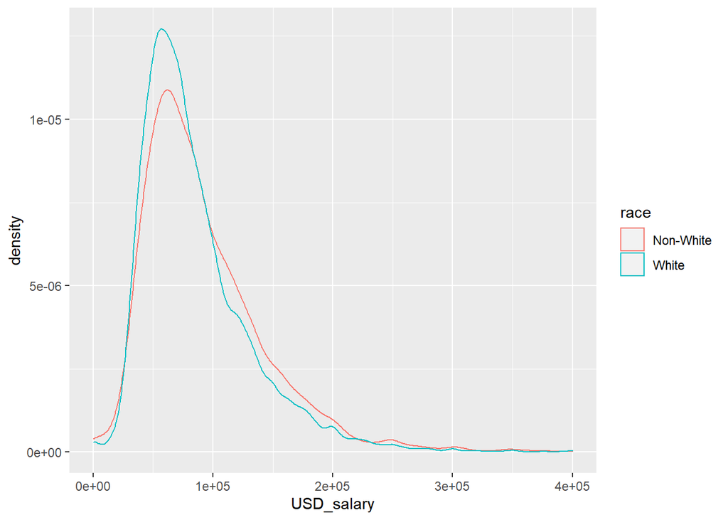

```r
ask_a_manager_2021_white_non_white %>%
  ggplot(aes(x= USD_salary, color = race)) +
  xlim(0,400000) +
 # theme(axis.text.x = element_text(angle=90, hjust=1)) +
  geom_density()
```

From the density plot of salary by race, we do not see a direct relationship of salary with race

Let us hypothesize that the mean salary of “White” is same as the mean salary of “Non-White”

```r
# hypothesis testing using t.test()
t.test(USD_salary ~ race, data = ask_a_manager_2021_white_non_white)
```

```
##
##  Welch Two Sample t-test
##
## data:  USD_salary by race
## t = 1.3632, df = 3678.6, p-value = 0.1729
## alternative hypothesis: true difference in means between group Non-White and group White is not equal to 0
## 95 percent confidence interval:
##  -16590.45  92308.99
## sample estimates:
## mean in group Non-White     mean in group White
##               124839.32                86980.05
```

```r
# hypothesis testing using infer package
infer_gender_salary <- ask_a_manager_2021_white_non_white %>%
  specify(USD_salary ~ race) %>%
  calculate(stat = "diff in means", order = c("White", "Non-White"))

null_dist <- ask_a_manager_2021_white_non_white %>%
  # specify variables
  specify(USD_salary ~ race) %>%

  # assume independence, i.e, there is no difference
  hypothesize(null = "independence") %>%

  # generate 1000 reps, of type "permute"
  generate(reps = 1000, type = "permute") %>%

  # calculate statistic of difference, namely "diff in means"
  calculate(stat = "diff in means", order = c("White", "Non-White"))
```

> The t-stat is 1.36 which is less than 2. It hence proves our hypothesis that the salary difference between “White” and “Non-White” people is negligible.

Let us further see with the help of confidence intervals, the difference in pay between “White” and “non White” people

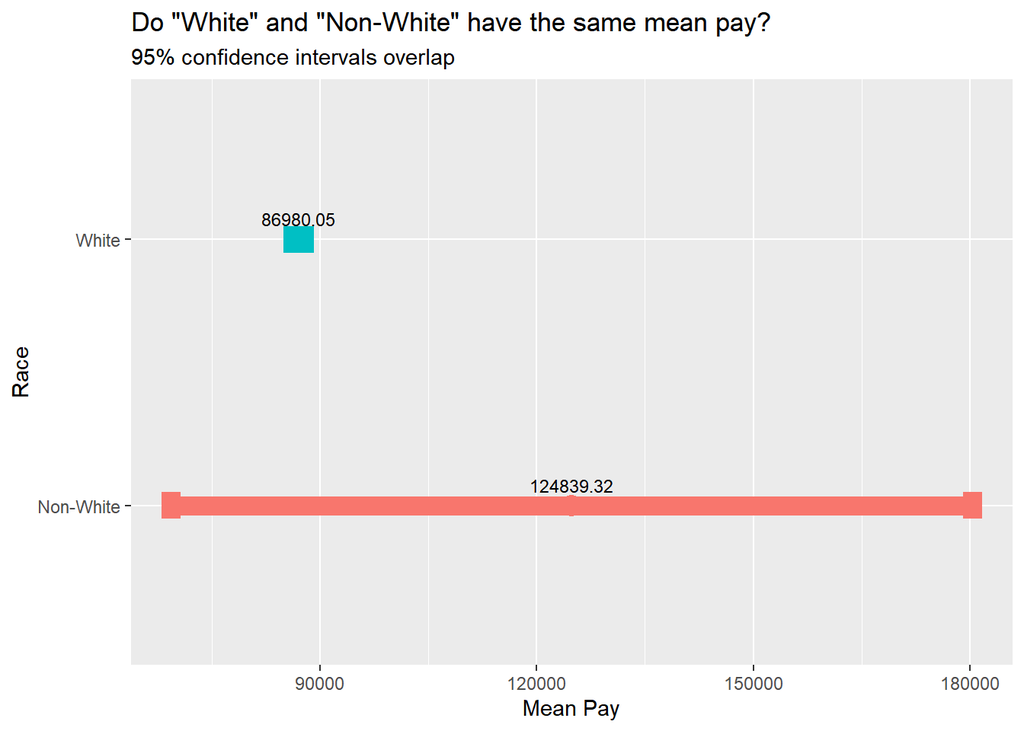

```r
  white_pay <- ask_a_manager_2021_white_non_white %>%
   filter(race == "White" ) %>%
  dplyr::summarise(race = "White",
            mean_pay = mean(USD_salary, na.rm=TRUE),
            SD_pay = sd(USD_salary, na.rm=TRUE),
            count_pay = n()) %>%
  mutate(SE_pay = SD_pay/sqrt(count_pay),
         lower_CI = mean_pay - (2*SE_pay),
         upper_CI = mean_pay + (2*SE_pay))

non_white_pay <- ask_a_manager_2021_white_non_white %>%
  filter(race == "Non-White") %>%
  dplyr::summarise(race = "Non-White",
            mean_pay = mean(USD_salary, na.rm=TRUE),
            SD_pay = sd(USD_salary, na.rm=TRUE),
            count_pay = n()) %>%
  mutate(SE_pay = SD_pay/sqrt(count_pay),
         lower_CI = mean_pay - (2*SE_pay),
         upper_CI = mean_pay + (2*SE_pay))

white_non_white_pay <- rbind(white_pay,non_white_pay)

ggplot(white_non_white_pay) +
geom_errorbar( aes(y =race ,xmin = lower_CI, xmax= upper_CI, width =0.1, size= 2, x=mean_pay, color = race)) +
  geom_point( aes(y = race, x= mean_pay, size = 2, color = race)) +
  geom_text(aes(x=mean_pay, y=race), label = round(white_non_white_pay$mean_pay,2),
            hjust=0.5, vjust=-1, size=3)  +
  theme(legend.position = "none") +
  labs(title= "Do \"White\" and \"Non-White\" have the same mean pay?", subtitle ="95% confidence intervals overlap",
      x ="Mean Pay", y="Race")
```

```r
white_non_white_pay
```

```
## # A tibble: 2 x 7
##   race      mean_pay   SD_pay count_pay SE_pay lower_CI upper_CI
##   <chr>        <dbl>    <dbl>     <int>  <dbl>    <dbl>    <dbl>
## 1 White       86980.   60862.     21902   411.   86158.   87803.
## 2 Non-White  124839. 1684081.      3678 27769.   69302.  180377.
```

But let us further divide it based on relevant work experience in the field and analyse

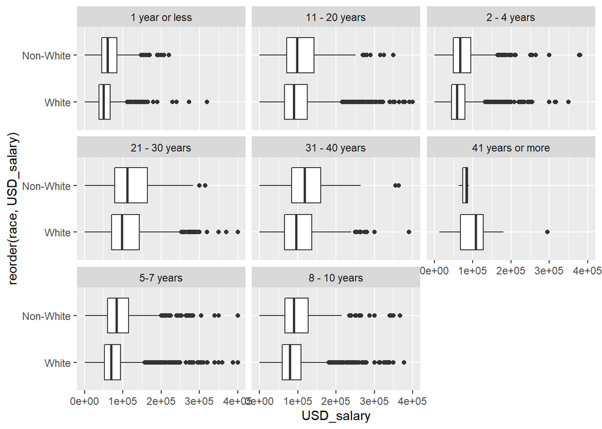

```r
ask_a_manager_2021_white_non_white %>%
  ggplot(aes(x= USD_salary, y=reorder(race, USD_salary))) +
  facet_wrap(~years_of_experience_in_field)+
  xlim(0,400000) +
 # theme(axis.text.x = element_text(angle=90, hjust=1)) +
  geom_boxplot()
```

> We see that the salary difference between “White” and “Non-white” is more pronounced for specific brackets of relevant work experience.

Let us also check the difference in pay for “White” and “Non-white” across industries

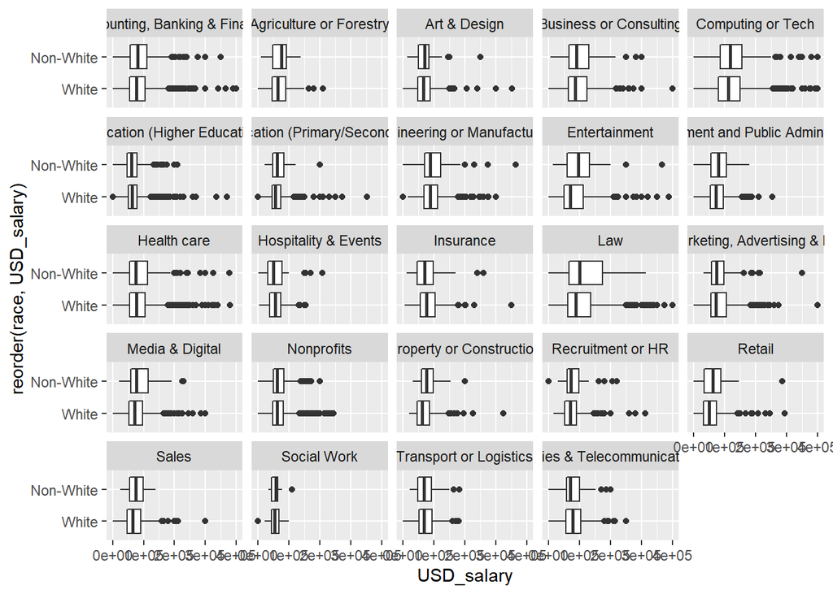

```r
ask_a_manager_2021_white_non_white_industry <- ask_a_manager_2021_white_non_white[ask_a_manager_2021_white_non_white$industry %in% industry_list,]

ask_a_manager_2021_white_non_white_industry %>%
  ggplot(aes(x= USD_salary, y=reorder(race, USD_salary))) +
  facet_wrap(~industry)+
  xlim(0,400000) +
 # theme(axis.text.x = element_text(angle=90, hjust=1)) +
  geom_boxplot()
```

The salary across all the industries seems similar for people belonging to “White” and “Non-White” race.

Let us see how the mean salary of other races compare

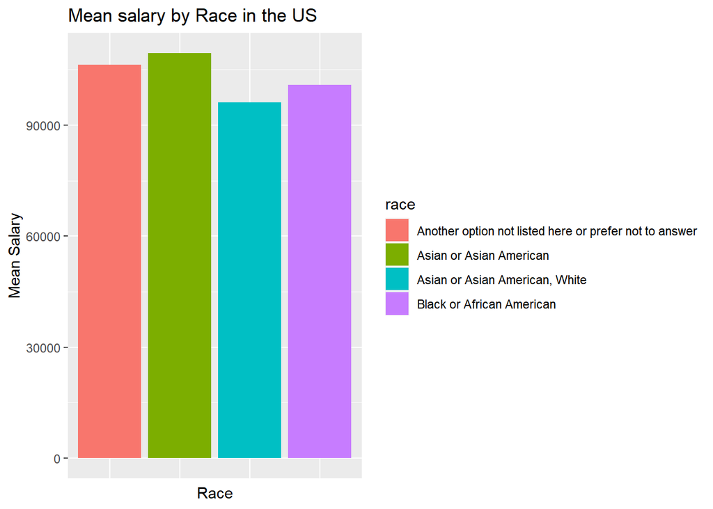

```r
ask_a_manager_2021_race %>%
  filter(country_code == "USA") %>%
  group_by(race) %>%
  summarise(mean_salary = mean(USD_salary)) %>%
  arrange(-mean_salary) %>%
  head(4) %>%
  ggplot(aes(x= race, y=mean_salary, fill = race)) +
  theme(axis.text.x=element_blank(),
        axis.ticks.x=element_blank()) +
  labs(title = "Mean salary by Race in the US", x= "Race", y= "Mean Salary") +
  geom_col()
```

> We see that the “Asian or Asian American” earn more than the other races in the US

> With our overall analysis by race, we saw that we did not see any noticeable difference in salaries between White and Non-White. In the US, the salary of “Asian or Asian American” is the highest

# 4 Analysis on Industry

```r
ask_a_manager_2021_industry %>%
  group_by(industry) %>%
  summarise(industry_count = n()) %>%
  arrange(-industry_count) %>%
  kable()
```

| industry | industry_count |
| --- | --- |
| Computing or Tech | 4334 |
| Education (Higher Education) | 2325 |
| Nonprofits | 2319 |
| Government and Public Administration | 1816 |
| Health care | 1742 |
| Accounting, Banking & Finance | 1679 |
| Engineering or Manufacturing | 1508 |
| Marketing, Advertising & PR | 1051 |
| Law | 1042 |
| Education (Primary/Secondary) | 794 |
| Business or Consulting | 777 |
| Media & Digital | 730 |
| Insurance | 493 |
| Retail | 450 |
| Recruitment or HR | 424 |
| Property or Construction | 350 |
| Utilities & Telecommunications | 328 |
| Art & Design | 325 |
| Transport or Logistics | 271 |
| Sales | 258 |
| Social Work | 258 |
| Entertainment | 234 |
| Hospitality & Events | 234 |
| Agriculture or Forestry | 127 |

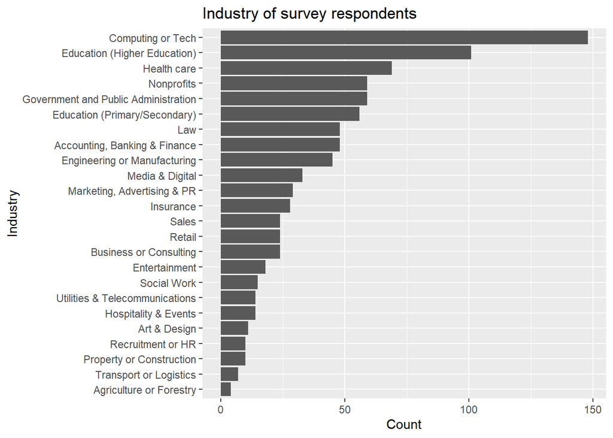

```r
ask_a_manager_2021_industry %>%
  group_by(industry) %>%
  na.omit() %>%
  summarise(industry_count = n()) %>%
  arrange(industry_count) %>%
  ggplot(industry_analysis, mapping = aes(x=industry_count, y=fct_reorder(industry,industry_count))) +
  geom_col() +
  labs(title="Industry of survey respondents", x="Count", y="Industry") +
  NULL
```

From this initial analysis, we can see that respondents work in many different industries, but the most reported working in the Computing or Tech industry.

## 4.1 Differences in Salaries accross Industries

Next, let’s see how salaries compare accross industries, and whether these differences are country-specific.

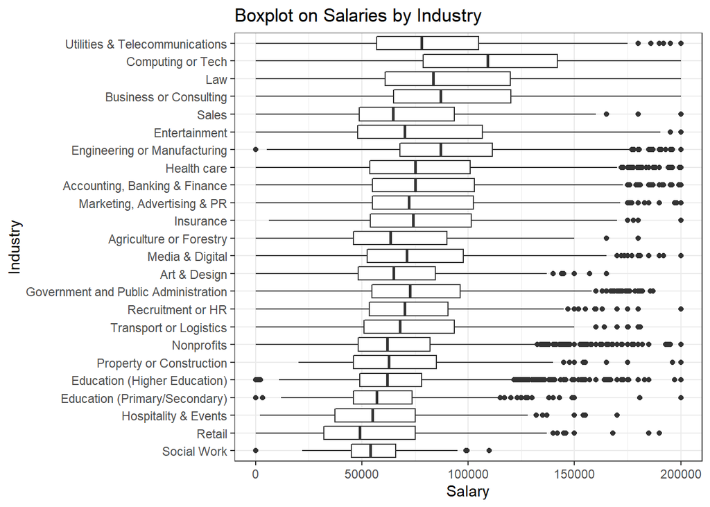

```r
ask_a_manager_2021_industry %>%
  group_by(industry) %>%
  arrange(industry) %>%
  ggplot(ask_a_manager_2021, mapping = aes(x=USD_salary, y=reorder(industry,USD_salary))) +
  scale_x_log10() +
  theme_bw() +
  xlim(0,200000) +
  geom_boxplot() +
  labs(title="Boxplot on Salaries by Industry", x="Salary", y="Industry") +
  NULL
```

Respondents in the Computing or Tech industry also respondent having the highest median salaries, followed by Engineering/Manufacturing, Business/Consulting and Law. Lowest median salaries occur in Retail, Hospitality & Events and Social Work.

Let’s do a null hypothesis to confirm/reject our initial observations. We could create a Null Hypothesis stating the mean sample for the lowest and highest paying industries are the same. However, that would be a bit boring. Let’s instead compare the two highest paying industries by median, Computing/Tech and Engineering/Manufacturing.

```r
ask_a_manager_industries <- ask_a_manager_2021_industry %>%
   filter(industry == "Computing or Tech" | industry == "Engineering or Manufacturing")

t.test(USD_salary ~ industry, data = ask_a_manager_industries)
```

```
##
##  Welch Two Sample t-test
##
## data:  USD_salary by industry
## t = 17.216, df = 4412.9, p-value < 2.2e-16
## alternative hypothesis: true difference in means between group Computing or Tech and group Engineering or Manufacturing is not equal to 0
## 95 percent confidence interval:
##  25918.70 32580.18
## sample estimates:
##            mean in group Computing or Tech
##                                  123383.75
## mean in group Engineering or Manufacturing
##                                   94134.32
```

```r
# hypothesis testing using infer package
infer_industry_salary <- ask_a_manager_industries %>%
  specify(USD_salary ~ industry) %>%
  calculate(stat = "diff in means", order = c("Computing or Tech", "Engineering or Manufacturing"))

null_dist <- ask_a_manager_industries %>%
  # specify variables
  specify(USD_salary ~ industry) %>%

  # assume independence, i.e, there is no difference
  hypothesize(null = "independence") %>%

  # generate 1000 reps, of type "permute"
  generate(reps = 1000, type = "permute") %>%

  # calculate statistic of difference, namely "diff in means"
  calculate(stat = "diff in means", order = c("Computing or Tech", "Engineering or Manufacturing"))
```

Even for the two highest paid industries, the t-stat for our hypothesis test is 17.215, which is more than our boundary of 2/-2. This leads us to reject the null hypothesis. Additionally, our p-value is less than 5%, which means that we are not likely to get a sampling error in our data. So we can assume that our alternative hypothesis is right, ie. that there is a difference between the salaries of both of these industries.

## 4.2 Variabilities in Salaries accross Industries

We’ve also observed huge variabilities in salaries compared by industries, with extreme outliers. Let’s thus have a closer look at these industries standard deviations’.

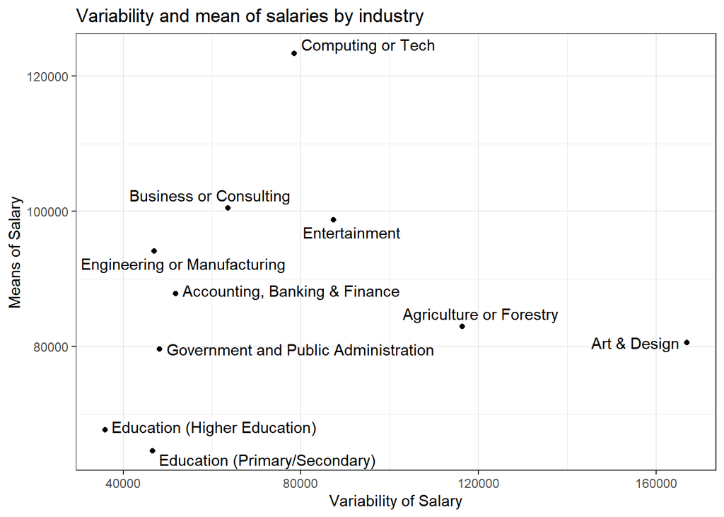

```r
ask_a_manager_2021_industry %>%
  group_by(industry) %>%
  summarise(salary_mean_byindustry = mean(USD_salary),
            salary_sd_byindustry = sd(USD_salary)) %>%
  arrange(industry) %>%
  slice(0:10) %>%
  ggplot(aes(x=salary_sd_byindustry, y=salary_mean_byindustry)) +
  geom_point() +
  theme_bw() +
  ggrepel::geom_text_repel(aes(label = industry)) +
  labs(title="Variability and mean of salaries by industry", x="Variability of Salary", y="Means of Salary") +
  NULL
```

> We can infer from the plot above that the Art & Design industry, while not being the highest paid industry on average, has huge variabilities in salaries. Same goes for the Agirculture/Forestry industry.

## 4.3 Geographical Differences in Salaries accross Industries

Let’s now have a geographical look at salaries by industry. Do some industries have higher average salaries in some countries, compared to others? For the sake of our analysis, let’s only look at the four countries with the most data.

```r
ask_a_manager_2021_industry %>%
  group_by(country_code) %>%
  summarise(country_code_count = n()) %>%
  arrange(- country_code_count) %>%
  head(4)
```

```
## # A tibble: 4 x 2
##   country_code country_code_count
##   <chr>                     <int>
## 1 USA                       19891
## 2 CAN                        1437
## 3 GBR                        1368
## 4 AUS                         335
```

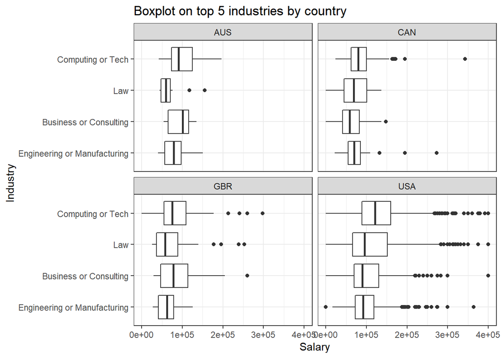

```r
ask_a_manager_2021_industry %>%
  filter(industry == "Computing or Tech" | industry == "Engineering or Manufacturing" |industry == "Business or Consulting" |industry == "Law" |industry == "Utilities or Telecommunications" ) %>%
  filter(country_code == "USA" | country_code == "CAN" | country_code == "GBR" | country_code == "AUS" ) %>%
  ggplot(aes(x= USD_salary, y=reorder(industry, USD_salary))) +
  facet_wrap(~country_code)+
  theme_bw() +
  xlim(0,400000) +
  geom_boxplot() +
  labs(title="Boxplot on top 5 industries by country", x="Salary", y="Industry") +
  NULL
```

## 4.4 Differences in Salaries and Experience accross Industries,

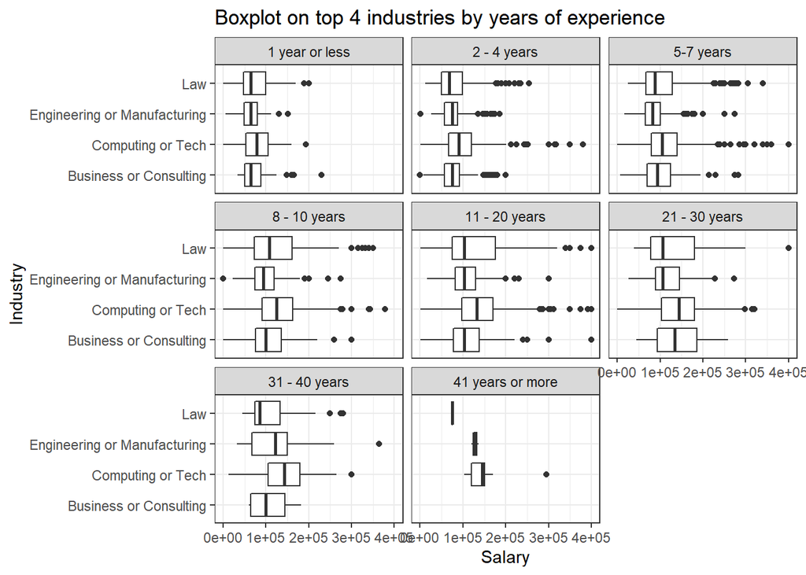

```r
ask_a_manager_2021_industry$years_of_experience_in_field <- factor(ask_a_manager_2021_industry$years_of_experience_in_field, levels = c("1 year or less", "2 - 4 years", "5-7 years" , "8 - 10 years", "11 - 20 years", "21 - 30 years", "31 - 40 years"  , "41 years or more"))

ask_a_manager_2021_industry %>%
  filter(industry == "Computing or Tech" | industry == "Engineering or Manufacturing" |industry == "Business or Consulting" |industry == "Law" |industry == "Utilities or Telecommunications" ) %>%
  ggplot(aes(x= USD_salary, y=industry)) +
  facet_wrap(~years_of_experience_in_field)+
  xlim(0,400000) +
  theme_bw() +
  geom_boxplot() +
  labs(title="Boxplot on top 4 industries by years of experience", x="Salary", y="Industry") +
  NULL
```

## 4.5 Impact of Education

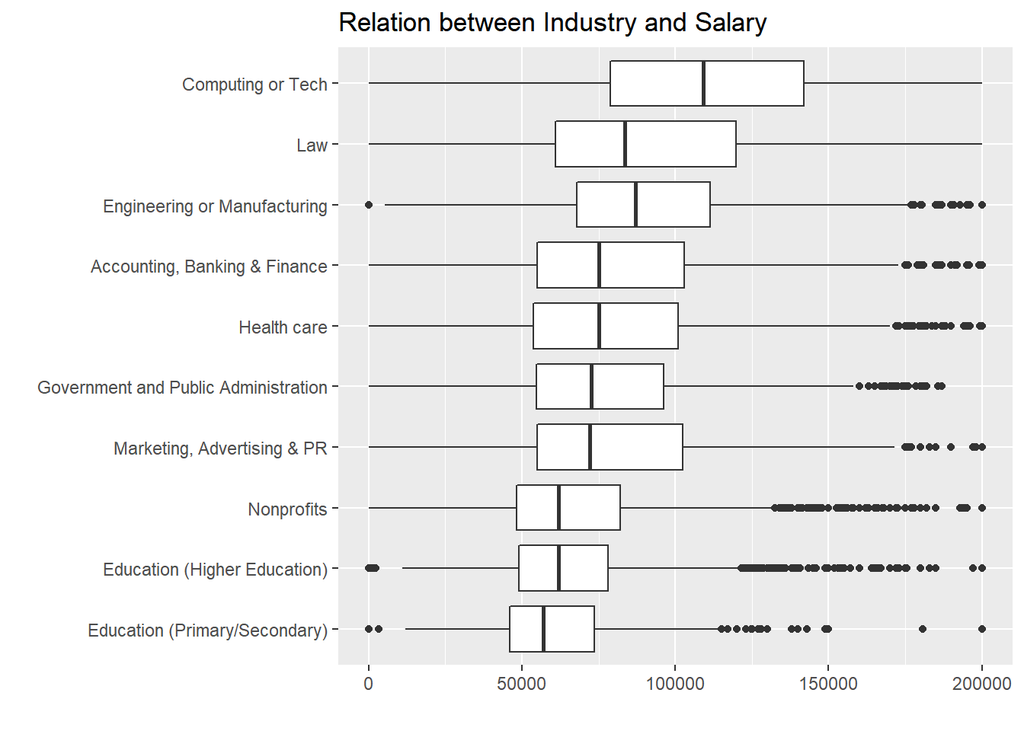

```r
#industry, salary, degree

#select the top ten industry, which contains the industry frequencies larger than 794
industry_list <- ask_a_manager_2021_industry %>%
  count(industry, sort=TRUE) %>%
  filter(n >= 794) %>%
  select(industry) %>%
  pull()

ask_a_manager_2021_industry_top10 <- ask_a_manager_2021_industry[ask_a_manager_2021_industry$industry %in% industry_list,]

#create a ggplot to look at the Relation between Industry and Salary
ggplot(ask_a_manager_2021_industry_top10,aes(y=fct_reorder(industry,USD_salary),x=USD_salary))+
  geom_boxplot()+
  xlim(0,200000)+
  labs(title="Relation between Industry and Salary", x="",y="")
```

> we can see that the computing and tech had the highest median sakary, while the primary and secondary education had the lowestmedian salary.

```r
#Relation between salary and degree

#create a table to look at each level of education
table(ask_a_manager_2021_industry$highest_level_of_education_completed)
```

```
##
##                     College degree                        High School
##                              11621                                510
##                    Master's degree                                PhD
##                               7653                               1146
## Professional degree (MD, JD, etc.)                       Some college
##                               1213                               1726
```

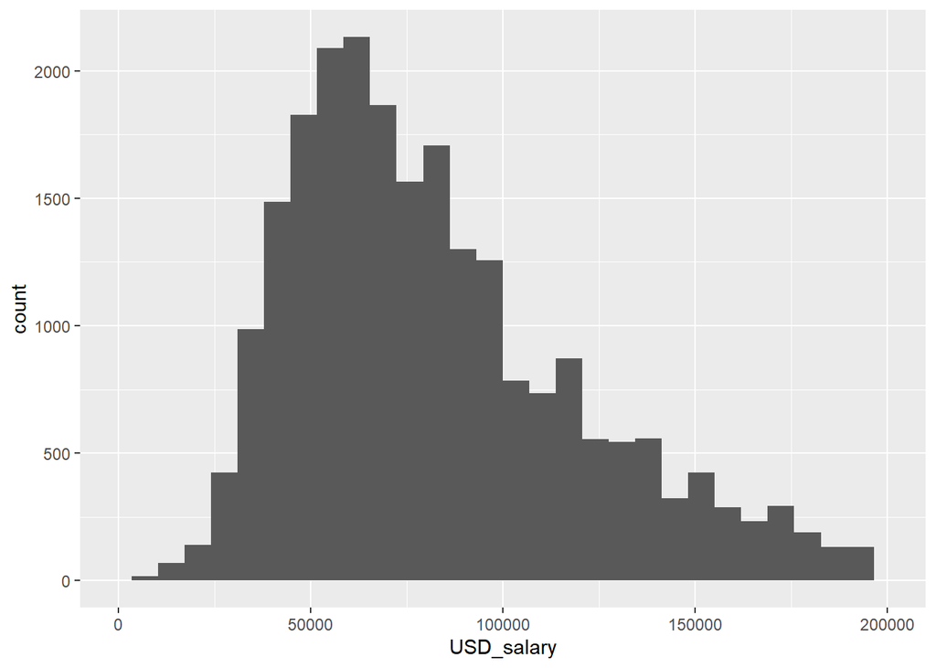

```r
#salary distribution
ggplot(ask_a_manager_2021_industry,aes(x=USD_salary))+
  geom_histogram()+
  xlim(0,200000)
```

```r
summary(ask_a_manager_2021_industry$USD_salary)
```

```
##      Min.   1st Qu.    Median      Mean   3rd Qu.      Max.
##         0     54723     75000     93778    109000 102000000
```

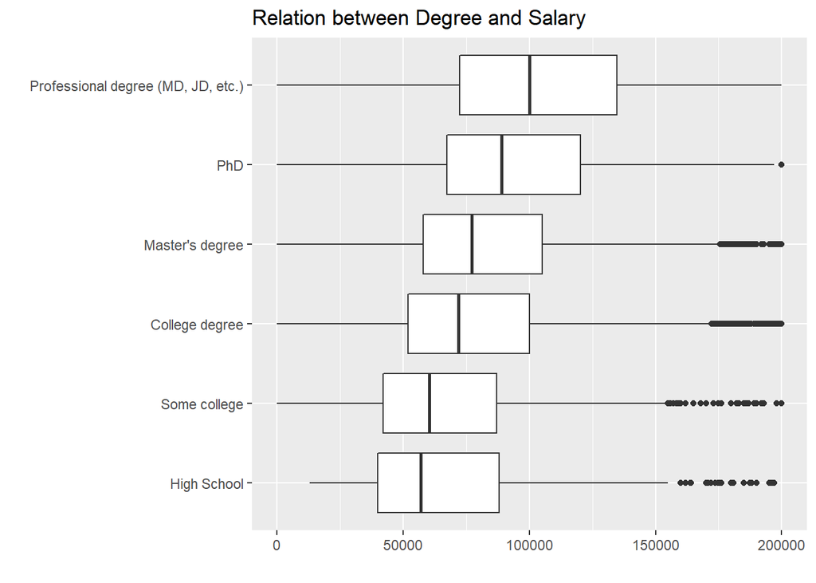

```r
#create boxplot to descrive the relationship between education and salary
ggplot(ask_a_manager_2021_industry,aes(y=fct_reorder(highest_level_of_education_completed,USD_salary),x=USD_salary))+
  geom_boxplot()+
  xlim(0,200000)+
  labs(title="Relation between Degree and Salary", x="",y="")
```

> In all, people with professional degree as their highest degree had the highest median salary, with the PhD degree coming behind it. People who had high school degree as their highest degree had lowest median salary.

```r
#Analyze the relationship between highest degree and the industry, trying to figure out what industry need what kinds of degree
table_industry_degree <- table(ask_a_manager_2021_industry_top10 $industry,ask_a_manager_2021_industry_top10$highest_level_of_education_completed)
addmargins(table_industry_degree)
```

```
##
##                                        College degree High School
##   Accounting, Banking & Finance                   952          51
##   Computing or Tech                              2524         126
##   Education (Higher Education)                    599          15
##   Education (Primary/Secondary)                   269           6
##   Engineering or Manufacturing                    835          22
##   Government and Public Administration            642          31
##   Health care                                     738          40
##   Law                                             243           9
##   Marketing, Advertising & PR                     741           4
##   Nonprofits                                     1091          16
##   Sum                                            8634         320
##
##                                        Master's degree   PhD
##   Accounting, Banking & Finance                    436    11
##   Computing or Tech                               1061   175
##   Education (Higher Education)                    1155   465
##   Education (Primary/Secondary)                    442    33
##   Engineering or Manufacturing                     478    88
##   Government and Public Administration             854    99
##   Health care                                      557    85
##   Law                                              108    20
##   Marketing, Advertising & PR                      235    10
##   Nonprofits                                       993    74
##   Sum                                             6319  1060
##
##                                        Professional degree (MD, JD, etc.)
##   Accounting, Banking & Finance                                        59
##   Computing or Tech                                                    42
##   Education (Higher Education)                                         41
##   Education (Primary/Secondary)                                        22
##   Engineering or Manufacturing                                         12
##   Government and Public Administration                                 96
##   Health care                                                         178
##   Law                                                                 610
##   Marketing, Advertising & PR                                           6
##   Nonprofits                                                           56
##   Sum                                                                1122
##
##                                        Some college   Sum
##   Accounting, Banking & Finance                 170  1679
##   Computing or Tech                             406  4334
##   Education (Higher Education)                   50  2325
##   Education (Primary/Secondary)                  22   794
##   Engineering or Manufacturing                   73  1508
##   Government and Public Administration           94  1816
##   Health care                                   144  1742
##   Law                                            52  1042
##   Marketing, Advertising & PR                    55  1051
##   Nonprofits                                     89  2319
##   Sum                                          1155 18610
```

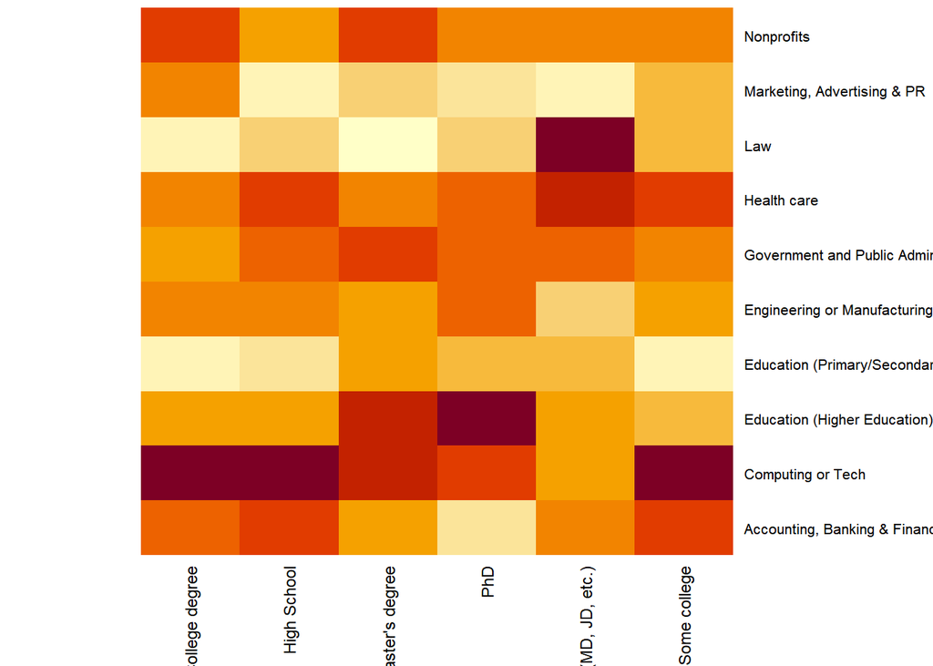

```r
matrix_industry_degree <- as.matrix(table_industry_degree)
for (i in 1:nrow(matrix_industry_degree)){
        for (j in 1:ncol(matrix_industry_degree)){
                matrix_industry_degree[i,j] <- log(matrix_industry_degree[i,j])
        }
}

heatmap(matrix_industry_degree,Rowv=NA,Colv=NA,scale="column",margins=c(5,3),cm.colors(256,start=02,end=0.5),cexRow=0.8,cexCol=0.9)
```

> We can see the relationship between highest education level and the industry. For industry like “Law”, most people with the professional degree such as JD, as the color is the darkest one. Another similar pattern is for higher education, where most people hold the PhD degree. For computing or tech industry, most people hold some college degree, high school degree and college degree for their highest education level. For health care industry, professional degree is needed, as the color was darker than other degree holders.